# Estudio sobre la relación entre las tecnologías que usan los desarrolladores en su trabajo y su salud mental

30 de junio del 2023

## Objetivos

### Objetivo principal

Demostrar que la salud mental del programador depende, en parte, del lenguaje de programación que escoja para trabajar.

### Objetivos secundarios

- Demostrar que la popularidad de un lenguaje de programación no significa que trabajar con este brinde un mejor estado de salud mental.
- Encontrar una relación entre el acceso a información del lenguaje de programación escogido por el programador y su salud mental.
- Encontrar una relación entre el salario que brinda el lenguaje de programación que usan los desarrolladores con su salud mental.
- Demostrar la relación entre el sistema operativo utilizado en el ámbito profesional y la salud mental de los individuos, y encontrar una posible asociación entre los problemas mentales y el tipo de sistema operativo.

## Probabilidad empírica

### Variable Total de Lenguajes de programación usados

Esta variable consta en la cantidad total de lenguajes de programación que los desarrolladores mencionaron usar. Se puede representar en un histograma:

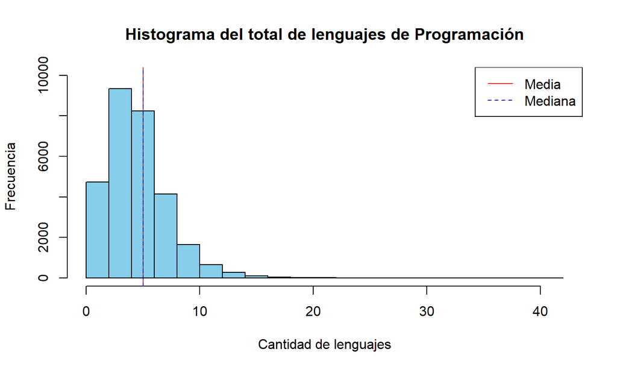

```r
hist(encuesta$TotalLenguages,
     col = "skyblue",
     main = "Histograma del total de lenguajes de Programación",
     xlab = "Cantidad de lenguajes",
     ylab = "Frecuencia",
     ylim = c(0,10000),
     breaks = 20
)

abline(v= mean(encuesta$TotalLenguages), col = "red", lty = 1)

abline(v= median(encuesta$TotalLenguages), col = "blue", lty = 2)

legend("topright", legend = c("Media", "Mediana"), col = c("red", "blue"), lty = c(1, 2))
```

Donde la media es: 4.9893165 y la mediana es: 5. Se aprecia que hay una mayor tendencia por trabajar con menos de 5 lenguajes de programación a diferencia con trabajar más de 5 lenguajes.

Espacio de probabilidad de la variable: \((\Omega,\mathcal{F},\mathbb{P})\)

Donde:

\[ \Omega = [42] - \{0\} = \text{ Cantidad de lenguajes de programación que usa } \\ \mathcal{F} = 2^\Omega = \text{ Subconjuntos de Omega } \\ \mathbb{P}(n) = \text{ Probabilidad de que use n lenguajes de programación } \]

Calculando las probabilidades empíricas de los eventos atómicos:

```r
encuesta %>% group_by(TotalLenguages) %>% count() -> probTotalLenguajes
probTotalLenguajes %>% rename(Frecuencia = n) -> probTotalLenguajes
probTotalLenguajes$ProbabilidadAtomica <- probTotalLenguajes$Frecuencia / nrow(encuesta)
probTotalLenguajes
```

```
## # A tibble: 28 × 3
## # Groups:   TotalLenguages [28]
##    TotalLenguages Frecuencia ProbabilidadAtomica
##             <dbl>      <int>               <dbl>
##  1              1       1631              0.0558
##  2              2       3103              0.106
##  3              3       4448              0.152
##  4              4       4891              0.167
##  5              5       4639              0.159
##  6              6       3609              0.124
##  7              7       2539              0.0869
##  8              8       1596              0.0547
##  9              9       1006              0.0344
## 10             10        645              0.0221
## # ℹ 18 more rows
```

Comprobamos que todos los eventos atómicos sumen 1:

```r
sum(probTotalLenguajes$ProbabilidadAtomica)
```

```
## [1] 1
```

#### Función de masa de probabilidad

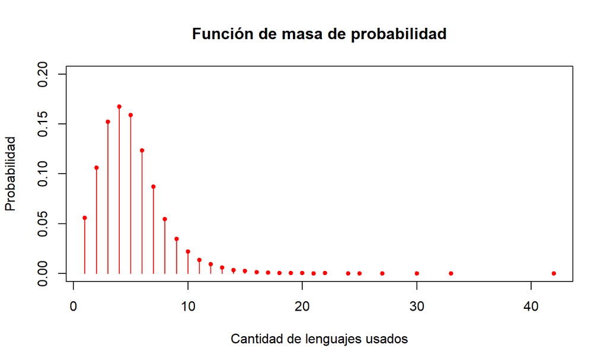

```r
plot(probTotalLenguajes$TotalLenguages,
     probTotalLenguajes$ProbabilidadAtomica,
     type = "h",
     col="red",
     main = "Función de masa de probabilidad",
     xlab = "Cantidad de lenguajes usados",
     ylab = "Probabilidad",
     ylim = c(0,0.2)
)

points(probTotalLenguajes$TotalLenguages,
     probTotalLenguajes$ProbabilidadAtomica,
     pch = 20,
     col="red",
)
```

Evidentemente, hay una mayor probabilidad de que un desarrollador trabaje con entre 3 a 5 lenguajes de programación, debido a que tienden a profesionalizarse más en unos pocos.

#### Función de masa de probabilidad acumulada

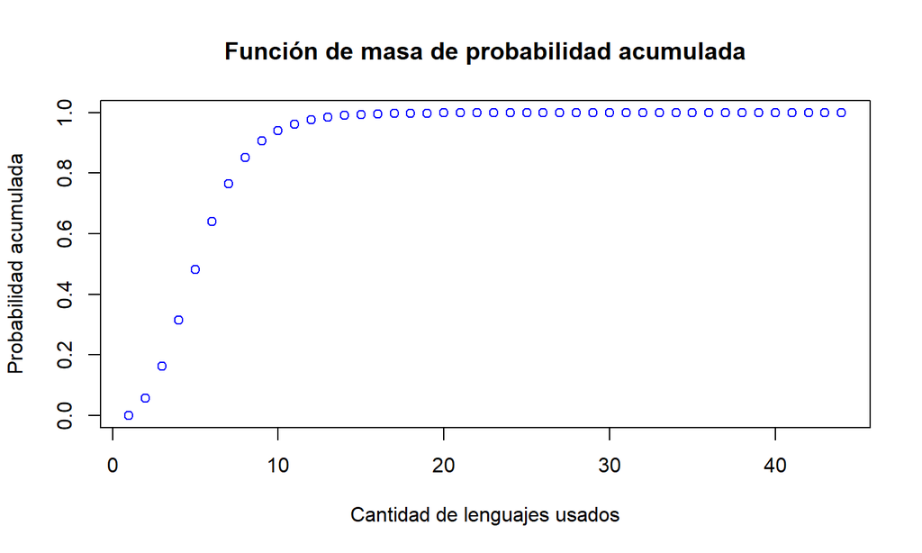

```r
probAcumulada <- ecdf(encuesta$TotalLenguages)

ecdf_datos <- probAcumulada(0:43)

plot(ecdf_datos,
     main = "Función de masa de probabilidad acumulada",
     xlab = "Cantidad de lenguajes usados",
     ylab = "Probabilidad acumulada",
     col = "blue",
)
```

### Variable cantidad de problemas de Salud Mental

Esta variable muestra la cantidad total de problemas de salud mental que los desarrolladores sufren. Se puede representar la frecuencia en un barplot:

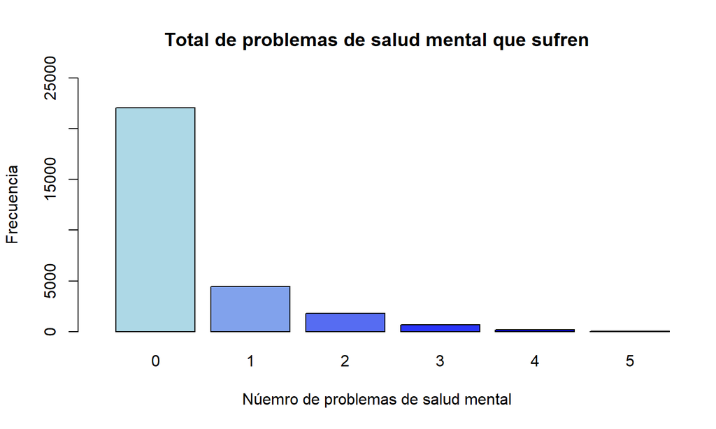

```r
BD <- data.frame("Memoria" = encuesta$Memoria,
                 "Ansiedad" = encuesta$Ansiedad,
                 "Aprendizaje" = encuesta$Aprendizaje,
                 "Autismo" = encuesta$Autismo,
                 "Emocional" = encuesta$Emocional)

BD$TabProb2 <- rowSums(BD)

TabProb2 <- data.frame(table(BD$TabProb2))
TabProb2 %>% rename(TotalMentalHealth = Var1, Frecuencia = Freq) -> TabProb2

barplot(TabProb2$Frecuencia,
        names.arg = TabProb2$TotalMentalHealth,
        main = "Total de problemas de salud mental que sufren",
        xlab = "Núemro de problemas de salud mental",
        ylab = "Frecuencia",
        col = colorRampPalette(c("lightblue", "blue"))(5),
        ylim = c(0,25000),
        xlim = c(0,7)
)
```

Donde claramente la moda es que no sufran ningún problema de salud mental.

Espacio de probabilidad de la variable: \((\Omega,\mathcal{F},\mathbb{P})\)

Donde:

\[ \Omega = [5] = \text{ Cantidad de problemas de salud mental que sufre } \\ \mathcal{F} = 2^\Omega = \text{ Subconjuntos de Omega } \\ \mathbb{P}(n) = \text{ Probabilidad de que sufra n problemas } \]

Calculando las probabilidades empíricas de los eventos atómicos:

```r
TabProb2$ProbabilidadAtomica <- ((as.numeric(TabProb2$Frecuencia)/nrow(encuesta)))

TabProb2
```

```
##   TotalMentalHealth Frecuencia ProbabilidadAtomica
## 1                 0      22074         0.755855362
## 2                 1       4430         0.151691549
## 3                 2       1817         0.062217504
## 4                 3        674         0.023079030
## 5                 4        174         0.005958088
## 6                 5         35         0.001198466
```

#### Función de masa de probabilidad

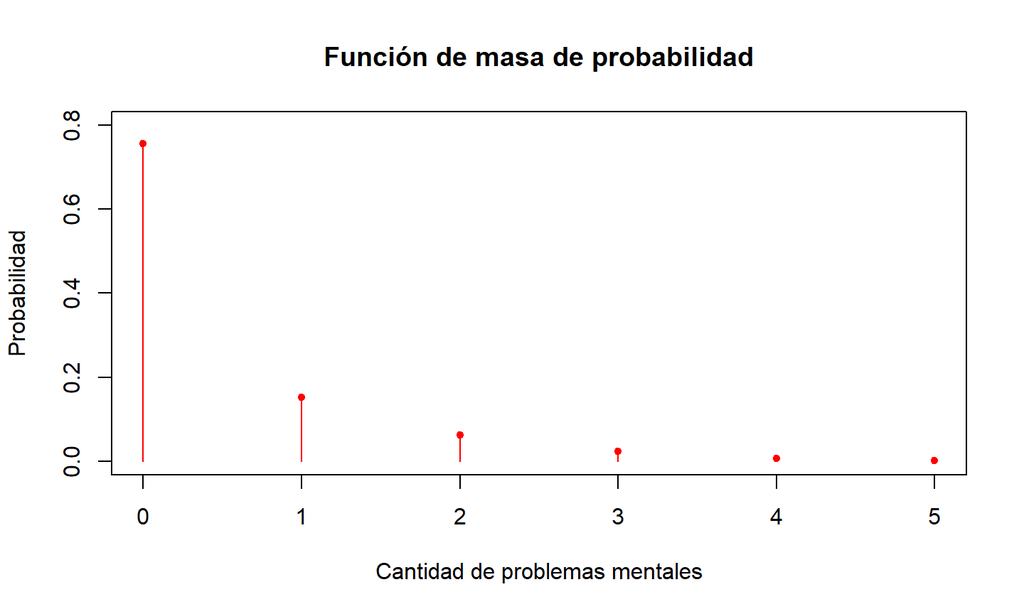

```r
plot(TabProb2$TotalMentalHealth,
     TabProb2$ProbabilidadAtomica,
     type = "h",
     col = "red",
     main = "Función de masa de probabilidad",
     ylab = "Probabilidad",
     xlab = "Cantidad de problemas mentales",
     ylim = c(0,0.8),
)

points(TabProb2$TotalMentalHealth,
     TabProb2$ProbabilidadAtomica,
     pch = 20,
     col="red",
)
```

Hay mayor probabilidad de que no sufra ningún problema de salud mental, pero existe la probabilidad de que sufra al menos 1 problema de salud mental

#### Función de masa de probabilidad acumulada

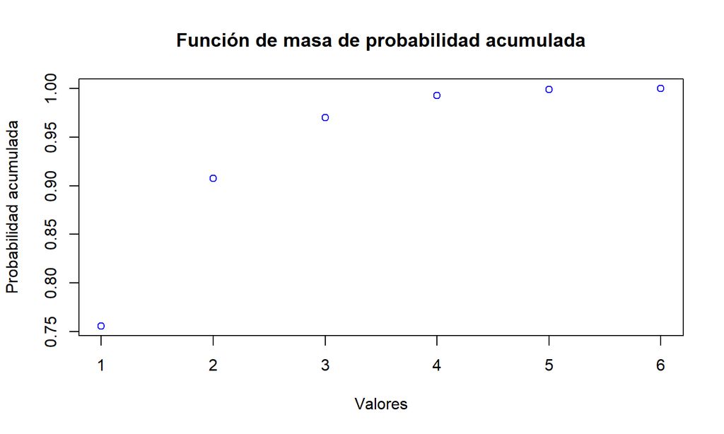

```r
probAcumulada <- ecdf(BD$TabProb2)

ecdf_datos <- probAcumulada(0:5)

plot(ecdf_datos,
     main = "Función de masa de probabilidad acumulada",
     xlab = "Valores",
     ylab = "Probabilidad acumulada",
     col = "blue"
)
```

## Probabilidad condicional (1)

### Eventos dependientes

- **Evento 1:** Las personas que trabajan con JavaScript y que tenga menos salario que el quartil del 15%
- **Evento 2:** Las personas que sufren de ansiedad

> Se espera que las personas que trabajan con JavaScript, al ser el lenguaje más usado entre los entrevistados, y que ganan cifras inferiores a la del quantil del 15% sufran de **ansiedad.** Esto debido a que sería frustrante para el programador usar un lenguaje famoso y no tener las ganancias esperadas.

### Quantil y probabilidades.

- Quantil del 15%:

```r
quantil <- quantile(encuesta$Salary, c(0.15), type = 6)
cat("El quantil del 15% del salario de los programadores es de:", quantil)
```

```
## El quantil del 15% del salario de los programadores es de: 23150
```

- Ganar menos que el quantil del 15% y trabajar en JS

```r
cantidad <- sum(encuesta$JavaScript == TRUE & encuesta$Salary < quantil, na.rm = TRUE)
cat("Probabilidad de trabajar en JS y ganar menos que el quantil",
    round(100*cantidad/nrow(encuesta),2), "%")
```

```
## Probabilidad de trabajar en JS y ganar menos que el quantil 10.88 %
```

- Sufrir de ansiedad

```r
cantAnsiedad <- sum(encuesta$Ansiedad[encuesta$Ansiedad == TRUE])
probabilidadAnsiedad <- cantAnsiedad/nrow(encuesta)
cat("La probabilidad de que alguien sufra de ansiedad es: ",
    round(100*probabilidadAnsiedad,2), "%")
```

```
## La probabilidad de que alguien sufra de ansiedad es:  10.67 %
```

### Mosaic Plot

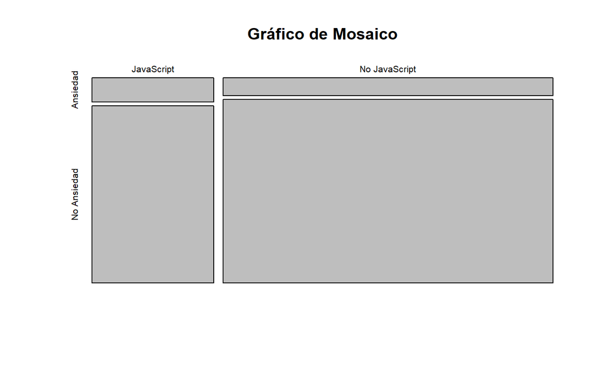

## Probabilidad Condicional (2)

### Eventos independientes

- **Evento 1:** Usa un lenguaje que está entre los 5 más populares.
- **Evento 2:** Sufre de 2 a más problemas mentales.

### Relación:

Queremos demostrar que nuestra salud mental no depende de si usamos un lenguaje **popular** o no. Para esto debemos demostrar que los eventos son **independientes:**

- P(E2|E1) = P(E2)
- P(E1|E2) = P(E1)

### Probabilidades de los eventos:

- Usa un lenguaje entre los 5 más populares

```r
#seleccionar los 5 más populares (Java, Javascript, C, Python y SQL)

java = encuesta$Java
javascirpt = encuesta$JavaScript
c = encuesta$C
python = encuesta$Python
sql = encuesta$SQL

evento1 = java | javascirpt | c | python | sql

#ahora calcularemos la probabilidad de que E1 sea verdadero

E1 = sum(evento1)/length(evento1)
rm(java, javascirpt, c, python, sql)

cat("la probabilidad del evento 1 es: ",E1, "%")
```

```
## la probabilidad del evento 1 es:  0.9318244 %
```

- Sufre de 2 o más problemas de salud mental

```r
#de la misma forma contaremos los problemas mentales que tiene cada persona
cantProblemas = encuesta$Memoria + encuesta$Emocional +encuesta$Ansiedad + encuesta$Autismo +encuesta$Aprendizaje

#ahora la probabilidad de tener 2 a más
E2 = length(cantProblemas[cantProblemas >= 2])/length(cantProblemas)

cat("Probabilidad del evento 2 es: ",E2, "%")
```

```
## Probabilidad del evento 2 es:  0.09245309 %
```

- Usa alguno de los 5 lenguajes más populares y sufre de 2 o más problemas de salud mental

```r
#uniremos ambas columnas y contaremos las que cumplen con E1 y E2
total = data.frame(evento1, cantProblemas)

#ahora contamos los que cumplen con ambas
E1E2 = nrow(total[total$evento1 == TRUE & total$cantProblemas >= 2,])/nrow(total)

cat("Prbabilidad del evento 1 y evento 2: ",E1E2, "%")
```

```
## Prbabilidad del evento 1 y evento 2:  0.08735105 %
```

#### ¿Son independientes?

```r
E2dadoE1 = E1E2/E1

cat("P(E2): ", round(E2, 4), "\n")
```

```
## P(E2):  0.0925
```

```r
cat("P(E2|E1): ", round(E2dadoE1, 4), "\n")
```

```
## P(E2|E1):  0.0937
```

```r
cat("diferencia entre lo esperado y lo obtenido:", round(abs(E2 - E2dadoE1),3))
```

```
## diferencia entre lo esperado y lo obtenido: 0.001
```

Y como la diferencia entre lo esperado y lo obtenido es **APROXIMADAMENTE** nula, podemos decir que son eventos independientes.

### Mosaic Plot

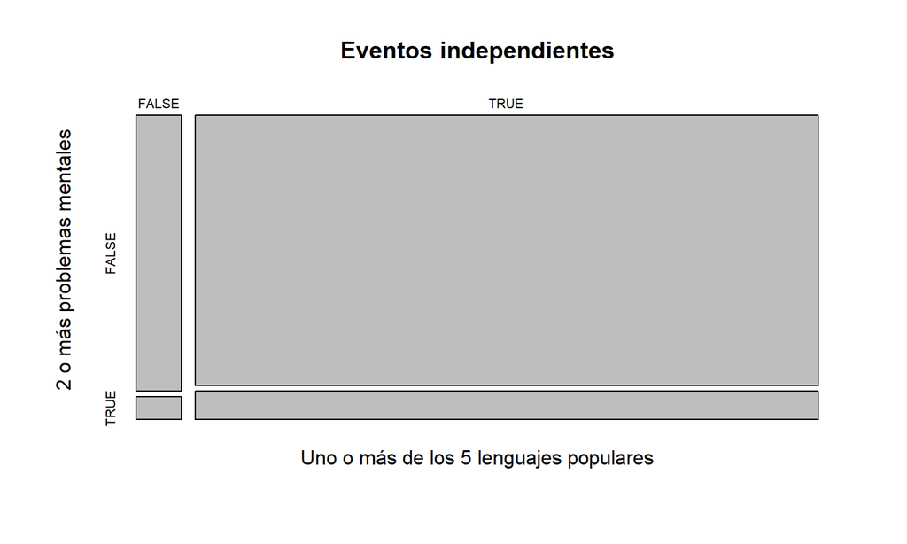

Se puede evidenciar en el **Mosaic Plot** que los eventos son **INDEPENDIENTES.**